# Unidad experimental

Gerardo Martín

3/2/2021

# 1 Introducción

En la sección de Tipos de experimentos y observaciones vimos brevemente que las observaciones que analizaremos pueden representar registros de individuos o grupos de individuos (plantas). En la sección El concepto de dato vimos que un dato es la descripción de las unidades experimentales, es decir que éstas pueden representar individuos o grupos de individuos, por lo que podemos definirla como:

- **Unidad experimental** Entidad sujeta a la intervención o tratamiento y que es *independiente* de las otras entidades dentro del estudio.

En esta definición hay que resaltar la palabra *independiente* pues es un supuesto muy importante para el análisis estadístico. Esta última se refiere a que el comportamiento de cada unidad experimental no afecta el comportamiento de las otras. Esto es muy difícil de lograr pues la proximidad espacial puede crear muchos artefactos que anulan los efectos de los tratamientos. Es por ello que en los análisis estadísticos es necesario tomar en cuenta los efectos del diseño sobre las hipótesis que queremos probar.

Tal como vimos que hay estudios observacionales, experimentales e intermedios, hay diseños experimentales donde las unidades comprenden observaciones de individuos y grupos.

# 2 Ejemplos

Estos ejemplos de unidades experimentales los he tomado de la [Iniciativa para reducir el uso de animales experimentales](http://www.3rs-reduction.co.uk/), sección de [unidades experimentales](http://www.3rs-reduction.co.uk/html/3__the_experimental_unit.html). La iniciativa contiene numerosos recursos para aprender y probar nuestros conocimientos y habilidades en diseño experimental, y fue creada co motivo de la publicación del libro [The Design of Animal Experiments](https://uk.sagepub.com/en-gb/eur/the-design-of-animal-experiments/book252408) (Festing et al. 2002).

## 2.1 Unidades con observaciones agrupadas o individuos

Las imágenes a continuación representan dos diseños experimentales similares pero con unidades experimentales muy diferentes:

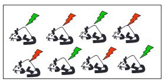

1. Medicamento aplicado por inyecciones

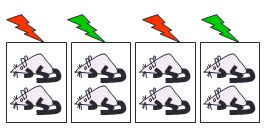

2. Medicamento aplicado en la comida

En el primer caso, todos los ratones están en el mismo contenedor, pero debido a que se aplica el tratamiento a cada individuo, existen **8 unidades experimentales**. En el segundo, hay cuatro contenedores cada uno con dos ratones y como el tratamiento se da en la comida, en este diseño sólo hay **4 unidades experimentales**.

## 2.2 Unidades con tratamientos secuenciales

Es posible aplicar tratamientos secuenciales en los mismos individuos, siempre y cuando éstos últimos no tengan efectos posteriores sobre los tratamientos subsecuentes. En la imágen de abajo, se tienen tres individuos, a los que se aplican cuatro tratamientos, por lo que hay **12 unidades experimentales**:

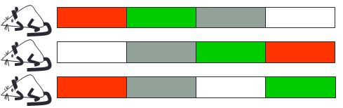

Tratamientos subsecuentes aplicados de manera aleatoria

## 2.3 Unidades con observaciones estrictamente agrupadas

El siguiente caso representa un tratamiento sobre dos hembras preñadas, pero los efectos se miden sobre la camada:

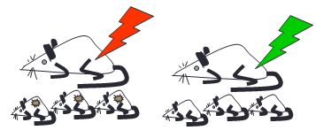

Tratamientos aplicados a madres, pero efectos medidos en los hijos

Tal que, aunque se toman datos de seis individuos, en realidad sólo existen **2 unidades experimentales**.

# 3 Discusión de los ejemplos

Los ejemplos aquí vistos muestran cómo el diseño experimental puede afectar en gran medida el tamaño de la muestra y recursos necesarios. En ocasiones, es posible maximizar el tamaño de muestra con decisiones técnicas sencillas (2.1), pero a veces es imposible aumentar el tamaño de muestra, pues ello está determinado por la naturaleza biológica del problema (2.3). Como veremos más adelante, el diseño también afecta nuestra habilidad para demostrar la efectividad de los tratamientos.

# 4 Verificación del aprendizaje

Regresar al índice del curso